# DSC5103 Assignment 1

## Part II: K-Nearest Neighbor Algorithm

### Introduction

In this assignment, we are going to experiment the K-Nearest Neighbor (KNN) algorithm on a higher-dimensional dataset and experience the deterioration of prediction performance as the dimensionality grows.

The experiment is built on top of the 3rd-order polynomial model discussed in class (knn_demo.R), i.e.,
$$y = \beta_0 + \beta_1 * x + \beta_2 * x^2 + \beta_3 * x^3 + \epsilon, ~~ \epsilon \sim \text{N}(0, \sigma^2)$$
and we are going to introduce an extra 20-dimensional predictor $z$, which does NOT actually play a role in generating $y$. Yet, when in estimation, we do not know the fact and will use both $x$ and $z$ as predictors in the KNN algorithm.

### Generation of the high-dimensional dataset

We first simulate the 3rd-order polynomial datasets as we did in knn_demo.R.

```r
library("ggplot2")

## population parameters
beta0 <- 1
beta1 <- -2
beta2 <- 6
beta3 <- -1
sigma <- 2

set.seed(7890)

## training data
x <- seq(0, 4.95, 0.05)
f_x <- beta0 + beta1 * x + beta2 * x^2 + beta3 * x^3
epsilon <- rnorm(n=100, mean=0, sd=sigma)
y <- f_x + epsilon

## test data
x.test <- seq(0, 5, 0.1)
f_x.test <- beta0 + beta1 * x.test + beta2 * x.test^2 + beta3 * x.test^3
epsilon.test <- rnorm(n=length(x.test), mean=0, sd=sigma)
y.test <- f_x.test + epsilon.test
```

The resulted training and test dataset have 100 and 51 data points, respectively.

Next, we need to generate $z$, the 20-dimensional predictors, of the same sizes. Each $z$ is a 20-dimensional multivariate normal random variable, with mean being $(0, 0, \ldots, 0)$ and identity covariance matrix (so that the 20 elements are independent standard normal random variables). The resulted $z$ is a 100*20 matrix, with each row being a data point with 20 dimensions.

```r
library("mvtnorm")  # package for multivariate normal distribution, INSTALL IT BEFORE RUNNING
z <- rmvnorm(n=100, mean=rep(0, 20))  # covariance matrix is identity matrix by default, no need to specify here
z.test <- rmvnorm(n=51, mean=rep(0, 20))
head(z)
```

```
##            [,1]        [,2]       [,3]       [,4]        [,5]       [,6]
## [1,] -1.9361316 -0.34358128 -1.1638774  0.1605231  2.20486714  0.1999970
## [2,]  0.2073874  0.08351621 -0.2201877  0.7665609  0.02909645 -0.7931468
## [3,] -0.6541246  0.01767131 -1.3381875 -1.5689372 -0.34894118  0.4083368
## [4,]  0.5405513 -0.97623013 -0.9655379 -1.2686342 -0.39747994 -1.7813696
## [5,] -0.7049465 -0.86347174 -0.2666028  0.0396169  0.97658103 -0.2921821
## [6,] -0.6152281  0.34972310  0.3442159 -2.4733329  1.60772672  0.9010075
##             [,7]       [,8]        [,9]      [,10]      [,11]      [,12]
## [1,]  0.63703376 -0.3163284 -0.04411668  1.8363856  0.5395264 -1.0504447
## [2,]  0.32640547 -1.2411995 -3.21302032 -1.7544576  1.1230329  0.5253656
## [3,] -1.34247876 -0.9201846  0.41490504 -0.6399194 -1.4481277  0.9424778
## [4,]  1.26541099 -0.9375670  1.19049543  0.2012602  1.7722236  1.3229934
## [5,] -0.03845784 -1.0264802  0.14979145 -0.4021824 -0.9955113 -1.5960321
## [6,] -0.12378738 -0.7137295 -0.74265059  1.0453174 -0.4778248  0.5921299
##            [,13]      [,14]      [,15]       [,16]      [,17]       [,18]
## [1,] -0.09930164  1.7060724  0.2533610 -2.29932737  0.6075511 -0.05006046
## [2,] -0.96761386  0.8290950 -2.3699198 -1.08936417  1.3503342 -0.37279404
## [3,]  1.77713823 -0.8249576 -0.5913526 -0.84274966  0.2850005  0.34198427
## [4,]  0.03379135  0.4903843 -0.2531970 -0.23792899  0.2704636 -0.08672554
## [5,]  0.53734820  0.9362600  0.7000580 -0.05312255  0.8395479  0.65372268
## [6,]  0.95070597 -0.5238348  0.5621953 -0.67832178 -0.5084597 -0.76040599
##           [,19]      [,20]
## [1,] -0.1269237 -0.9816281
## [2,]  0.6210679 -0.5312891
## [3,]  0.4387673  0.3632285
## [4,]  0.7263930 -1.7324591
## [5,] -0.3007821 -0.4409981
## [6,] -0.9644197 -1.7722140
```

Later, we will use $(x, z)$ to predict $y$. Let’s first combine $x$ and $z$ into matrices, as required by function knn.reg().

```r
train.x <- cbind(x, z)
test.x <- cbind(x.test, z.test)
head(train.x)
```

```
##         x
## [1,] 0.00 -1.9361316 -0.34358128 -1.1638774  0.1605231  2.20486714
## [2,] 0.05  0.2073874  0.08351621 -0.2201877  0.7665609  0.02909645
## [3,] 0.10 -0.6541246  0.01767131 -1.3381875 -1.5689372 -0.34894118
## [4,] 0.15  0.5405513 -0.97623013 -0.9655379 -1.2686342 -0.39747994
## [5,] 0.20 -0.7049465 -0.86347174 -0.2666028  0.0396169  0.97658103
## [6,] 0.25 -0.6152281  0.34972310  0.3442159 -2.4733329  1.60772672
##
## [1,]  0.1999970  0.63703376 -0.3163284 -0.04411668  1.8363856  0.5395264
## [2,] -0.7931468  0.32640547 -1.2411995 -3.21302032 -1.7544576  1.1230329
## [3,]  0.4083368 -1.34247876 -0.9201846  0.41490504 -0.6399194 -1.4481277
## [4,] -1.7813696  1.26541099 -0.9375670  1.19049543  0.2012602  1.7722236
## [5,] -0.2921821 -0.03845784 -1.0264802  0.14979145 -0.4021824 -0.9955113
## [6,]  0.9010075 -0.12378738 -0.7137295 -0.74265059  1.0453174 -0.4778248
##
## [1,] -1.0504447 -0.09930164  1.7060724  0.2533610 -2.29932737  0.6075511
## [2,]  0.5253656 -0.96761386  0.8290950 -2.3699198 -1.08936417  1.3503342
## [3,]  0.9424778  1.77713823 -0.8249576 -0.5913526 -0.84274966  0.2850005
## [4,]  1.3229934  0.03379135  0.4903843 -0.2531970 -0.23792899  0.2704636
## [5,] -1.5960321  0.53734820  0.9362600  0.7000580 -0.05312255  0.8395479
## [6,]  0.5921299  0.95070597 -0.5238348  0.5621953 -0.67832178 -0.5084597
##
## [1,] -0.05006046 -0.1269237 -0.9816281
## [2,] -0.37279404  0.6210679 -0.5312891
## [3,]  0.34198427  0.4387673  0.3632285
## [4,] -0.08672554  0.7263930 -1.7324591
## [5,]  0.65372268 -0.3007821 -0.4409981
## [6,] -0.76040599 -0.9644197 -1.7722140
```

### Questions

#### 1. For a fixed $k=15$, fit a KNN model to predict $y$ with $(x, z)$, and measure the training and test MSE. (1 Mark)

Answer:

```r
library("FNN")

# 1.measure the training MSE
model15.train <- knn.reg(train=train.x, test=train.x, y=y, k=15)
str(model15.train)
```

```
## List of 7
##  $ call     : language knn.reg(train = train.x, test = train.x, y = y, k = 15)
##  $ k        : num 15
##  $ n        : int 100
##  $ pred     : num [1:100] 6.32 6.85 8.25 6.28 5.52 ...
##  $ residuals: NULL
##  $ PRESS    : NULL
##  $ R2Pred   : NULL
##  - attr(*, "class")= chr "knnReg"
```

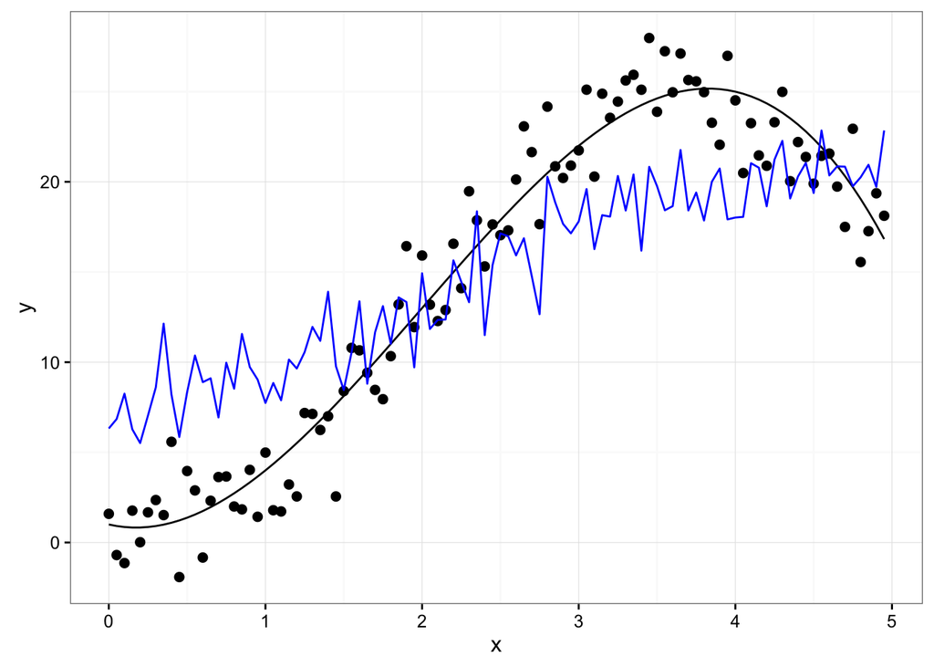

```r
# plot the fit
plot.train <- ggplot() + geom_point(aes(x=x, y=y), size=2) + geom_line(aes(x=x, y=f_x)) + theme_bw()
plot.train + geom_line(aes(x=x, y=model15.train$pred), col="blue")
```

```r
# Training MSE
mean((y - model15.train$pred)^2)
```

```
## [1] 25.27996
```

```r
# 2.measure the test MSE
model15.test <- knn.reg(train=train.x, test=test.x, y=y, k=15)
str(model15.test)
```

```
## List of 7
##  $ call     : language knn.reg(train = train.x, test = test.x, y = y, k = 15)
##  $ k        : num 15
##  $ n        : int 51
##  $ pred     : num [1:51] 6 6.89 6.51 6.68 12.45 ...
##  $ residuals: NULL
##  $ PRESS    : NULL
##  $ R2Pred   : NULL
##  - attr(*, "class")= chr "knnReg"
```

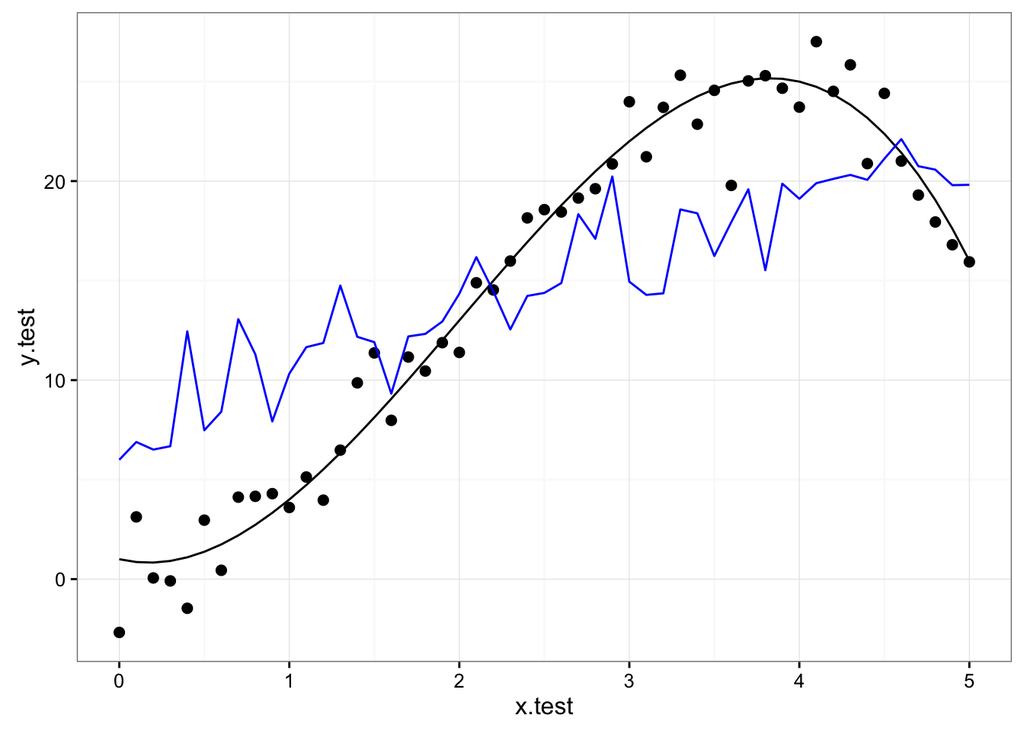

```r
# plot the fit
plot.test <- ggplot() + geom_point(aes(x=x.test, y=y.test), size=2) + geom_line(aes(x=x.test, y=f_x.test)) + theme_bw()
plot.test + geom_line(aes(x=x.test, y=model15.test$pred), col="blue")
```

```r
# Test MSE
mean((y.test - model15.test$pred)^2)
```

```
## [1] 30.90956
```

#### 2. With the same data, plot the training and test MSE of the KNN model against $k$, and find the optimal $k$ and the corresponding test MSE. (1 Mark)

Answer:

```r
# put your R code here inside the blocks
# k's that will be evaluated
ks <- 1:50
# construct empty vectors for keeping the MSE for each k
mse.train <- numeric(length=length(ks))
mse.test  <- numeric(length=length(ks))

# loop over all the k and evaluate MSE in each of them
for (i in seq(along=ks)) {
    model.train <- knn.reg(train.x, train.x, y, k=ks[i])
    model.test  <- knn.reg(train.x, test.x, y, k=ks[i])
    mse.train[i] <- mean((y - model.train$pred)^2)
    mse.test[i] <- mean((y.test - model.test$pred)^2)
}
mse.train
```

```
##  [1]  0.00000 13.44851 15.40687 17.87187 16.85736 16.35781 19.15542
##  [8] 20.73851 21.32666 21.94045 22.59267 23.30333 24.24809 24.07687
## [15] 25.27996 26.65289 27.45065 28.95038 29.84570 31.44479 32.56622
## [22] 32.97976 34.12066 35.18099 36.75183 37.39806 37.41895 39.04934
## [29] 39.29471 39.84186 40.83308 41.98540 42.83554 44.11708 44.63381
## [36] 45.18326 45.83866 46.37908 46.75169 47.62955 48.21834 48.70093
## [43] 49.32711 50.10741 50.54767 51.12537 51.74747 51.96256 52.17269
## [50] 52.79273
```

```r
mse.test
```

```
##  [1] 75.38950 47.41891 45.61282 33.96436 28.45206 29.69826 28.85134
##  [8] 28.82283 30.05319 30.22976 28.41302 28.47921 28.26073 31.52024
## [15] 30.90956 31.58330 31.19329 32.19299 32.51377 33.56734 36.35270
## [22] 37.45248 37.70311 38.82965 39.24606 38.95774 39.29131 40.89234
## [29] 41.69166 41.84667 41.89004 41.57356 42.40455 43.36702 43.23572
## [36] 43.73135 44.01357 44.70413 44.85428 45.44270 45.88430 46.38662
## [43] 46.96521 47.55390 47.57976 48.42272 48.51269 49.02297 49.52376
## [50] 50.81194
```

```r
# optimal k
k.opt <- ks[which.min(mse.test)]
k.opt
```

```
## [1] 13
```

```r
# optimal MSE
mse.opt <- min(mse.test)
mse.opt
```

```
## [1] 28.26073
```

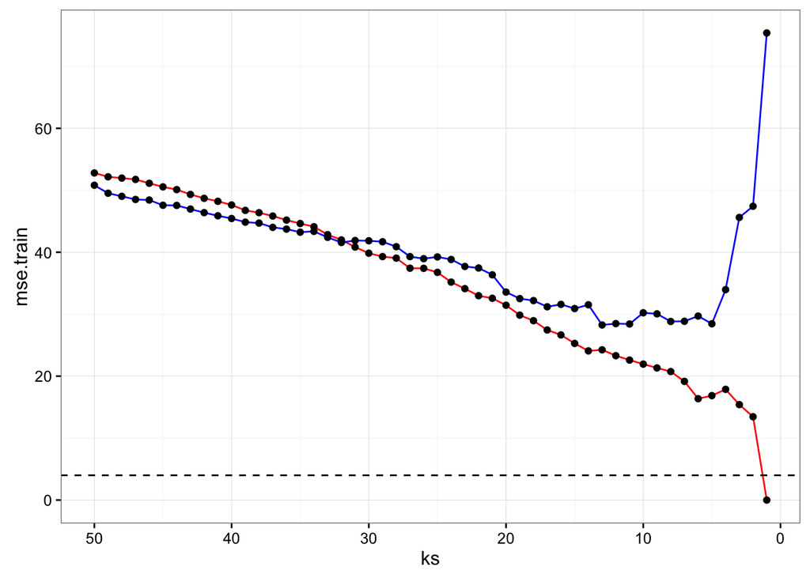

```r
# plot MSE on Training and Test
ggplot() + geom_line(aes(x=ks, y=mse.train), color="red") + geom_point(aes(x=ks, y=mse.train)) + geom_line(aes(x=ks, y=mse.test), color="blue") + geom_point(aes(x=ks, y=mse.test)) + scale_x_reverse(lim=c(50, 1)) + geom_hline(yintercept=sigma^2, linetype=2) + theme_bw()
```

#### 3. Based on the analysis above, compare the above model with $(x, z)$ being the predictors and the previous model with $x$ only (as in knn_demo.R). Briefly explain why. (1 Mark)

Answer: In the previous model, the optimal k was 8 and the optimal MSE was merely 3.830043 while in the above model, the optimal k is 13 and the optimal MSE is 28.260728, much larger. The reason for the change is that the additional 20 dimensions greatly increased the variation of the prediction.

#### 4. We have seen that the test MSE is significantly worse than what we had without using predictor $z$ (in knn_demo.R). To better understand the impact of including irrelevant predictors in the KNN algorithm, let’s try to include the 20 dimensions of $z$ one by one. So in each round $j$, we construct the predictors by combining $x$ and the first $j$ columns of $z$, then repeat the analysis in Question 2 and find the optimal $k$ and test MSE. At the end, plot the optimal MSE agaist $j$, and interpret the result. (1 Mark)

Answer:

```r
# put your R code here inside the blocks
ks <- 1:30
mse.train <- numeric(length=length(ks))
mse.test  <- numeric(length=length(ks))
train.x.opt <- x
test.x.opt <- x.test

for (j in 1:20) {
  train.x.opt <- cbind(train.x.opt,z[,j])
  test.x.opt <- cbind(test.x.opt,z.test[,j])

  # loop over all the k and evaluate MSE in each of them
  for (i in seq(along=ks)) {
      model.train <- knn.reg(train.x.opt, train.x.opt, y, k=ks[i])
      model.test  <- knn.reg(train.x.opt, test.x.opt, y, k=ks[i])
      mse.train[i] <- mean((y - model.train$pred)^2)
      mse.test[i] <- mean((y.test - model.test$pred)^2)
  }

  # optimal k
  k.opt[j] <- ks[which.min(mse.test)]
  # optimal MSE
  mse.opt[j] <- min(mse.test)
}

opt <- cbind(1:20, k.opt, mse.opt)
opt
```

```
##          k.opt   mse.opt
##  [1,]  1    12  4.953528
##  [2,]  2    16  7.540508
##  [3,]  3     6  8.961909
##  [4,]  4    10 11.927587
##  [5,]  5    10 10.810757
##  [6,]  6     8 10.242140
##  [7,]  7     8  9.994926
##  [8,]  8     6 13.494101
##  [9,]  9     6 16.362743
## [10,] 10     4 18.167512
## [11,] 11     3 18.776158
## [12,] 12    14 21.496731
## [13,] 13     5 18.865934
## [14,] 14     4 19.315693
## [15,] 15     9 23.045032
## [16,] 16    12 24.593636
## [17,] 17     3 25.720287
## [18,] 18     8 22.675506
## [19,] 19     5 24.481375
## [20,] 20    13 28.260728
```

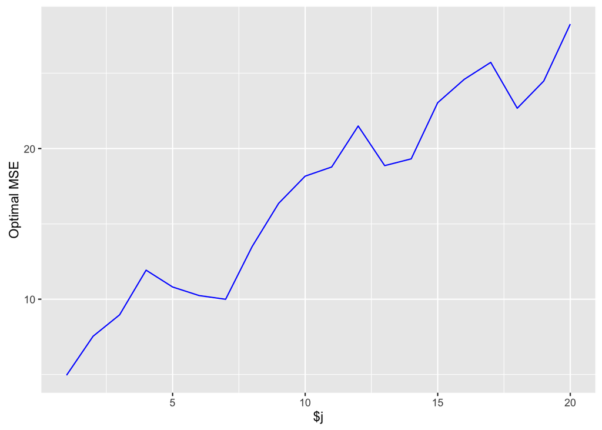

```r
MSEplot <- ggplot() + geom_line(aes(x=1:20, y=mse.opt),col = "blue") +scale_x_continuous("$j") + scale_y_continuous("Optimal MSE")
MSEplot
```

interpret: as j increases, the optimal MSE shows an increasing trend. the least optimal MSE value is when j=1. It means, by adding more irrelevant predictors in the KNN algorithm, the prediction can be more and more inaccurate.